# hw3

2026-02-22

## Problem 1: Newton’s Method for Logistic Regression

Let $Y_i \in \{0,1\}$ and $x_i = (1, X_{1i}, \dots, X_{pi})^\top \in \mathbb{R}^{p+1}$ include an intercept. Let $\beta \in \mathbb{R}^{p+1}$ and define
$$\eta_i = x_i^\top \beta, \qquad
\pi_i = P(Y_i=1 \mid x_i) = \frac{\exp(\eta_i)}{1+\exp(\eta_i)}.$$

### (a) Likelihood and log-likelihood

Because $Y_i \mid x_i \sim \mathrm{Bernoulli}(\pi_i)$, the likelihood is
$$L(\beta) = \prod_{i=1}^n \pi_i^{y_i}(1-\pi_i)^{1-y_i}.$$
Taking logs,
$$\ell(\beta) = \sum_{i=1}^n \left[ y_i \log(\pi_i) + (1-y_i)\log(1-\pi_i)
\right].$$
Using $\pi_i = \frac{e^{\eta_i}}{1+e^{\eta_i}}$, a common equivalent form is
$$\ell(\beta)=\sum_{i=1}^n \left[y_i \eta_i -
\log\!\left(1+e^{\eta_i}\right)\right].$$

### (b) Score function (gradient)

Let $X \in \mathbb{R}^{n\times(p+1)}$ be the design matrix with $i$-th row $x_i^\top$, $y=(y_1,\dots,y_n)^\top$, and $\pi=(\pi_1,\dots,\pi_n)^\top$. Then the score (gradient) is
$$\nabla \ell(\beta) = \sum_{i=1}^n x_i (y_i-\pi_i) = X^\top (y-\pi).$$

### (c) Hessian

Note that
$$\frac{\partial \pi_i}{\partial \beta} = \pi_i(1-\pi_i)\,x_i.$$
Therefore the Hessian is
$$\nabla^2 \ell(\beta) = -\sum_{i=1}^n \pi_i(1-\pi_i)\, x_i x_i^\top.$$
In matrix form, define $W = \mathrm{diag}(w_1,\dots,w_n)$ with $w_i=\pi_i(1-\pi_i)$. Then
$$\nabla^2 \ell(\beta) = -X^\top W X.$$

### (d) Newton’s method update

Newton’s method for maximizing $\ell(\beta)$ is
$$\beta^{(k+1)}=\beta^{(k)}-\left[\nabla^2\ell(\beta^{(k)})\right]^{-1}\nabla\ell(\beta^{(k)}).$$
Substituting the expressions above gives
$$\beta^{(k+1)}
= \beta^{(k)} + \left(X^\top W^{(k)} X\right)^{-1} X^\top
\left(y-\pi^{(k)}\right),$$
where $\pi^{(k)} = \pi(\beta^{(k)})$ and $W^{(k)}=\mathrm{diag}\!\big(\pi_i^{(k)}(1-\pi_i^{(k)})\big)$. This is the standard Newton/IRLS update for logistic regression.

### (e) Is logistic regression a convex optimization problem?

The Hessian of the log-likelihood is
$$\nabla^2 \ell(\beta) = -X^\top W X,$$
and since $W \succeq 0$ (each $w_i=\pi_i(1-\pi_i)\ge 0$), we have $X^\top W X \succeq 0$, so
$$\nabla^2 \ell(\beta) \preceq 0.$$
Thus $\ell(\beta)$ is concave in $\beta$. Equivalently, the negative log-likelihood $-\ell(\beta)$ is convex, so minimizing $-\ell(\beta)$ is a convex optimization problem (and the MLE is a global optimum).

## Problem 2: MM

Consider the logistic regression log-likelihood (up to an additive constant)
$$\ell(\theta)=\sum_{i=1}^n Y_i\,x_i^\top\theta-\sum_{i=1}^n
\log\!\left\{1+\exp(x_i^\top\theta)\right\},$$
where $x_i=(X_{i1},\dots,X_{ip})^\top$ and $\theta=(\theta_1,\dots,\theta_p)^\top$. Let the current iterate be $\theta^{(k)}$ and define
$$u_i(\theta)=x_i^\top\theta,\qquad u_i^{(k)}=x_i^\top\theta^{(k)}.$$

### (A) Prove the inequality (eliminating the log terms)

Define the convex function
$$\phi(u)=\log\{1+\exp(u)\}.$$
We have
$$\phi'(u)=\frac{\exp(u)}{1+\exp(u)},\qquad
\phi''(u)=\frac{\exp(u)}{(1+\exp(u))^2}\ge 0,$$
so $\phi$ is convex. By the supporting hyperplane (tangent line) inequality for convex functions,
$$\phi(u)\ \ge\ \phi(u_0)+\phi'(u_0)\,(u-u_0)\qquad \text{for all }u,$$
with equality at $u=u_0$. Set $u=u_i(\theta)=x_i^\top\theta$ and $u_0=u_i^{(k)}=x_i^\top\theta^{(k)}$. Then
$$\log\{1+\exp(x_i^\top\theta)\}
\ge
\log\{1+\exp(x_i^\top\theta^{(k)})\}
+\frac{\exp(x_i^\top\theta^{(k)})}{1+\exp(x_i^\top\theta^{(k)})}\Big(x_i^\top\theta-x_i^\top\theta^{(k)}\Big).$$
Multiply both sides by $-1$:
$$-\log\{1+\exp(x_i^\top\theta)\}
\le
-\log\{1+\exp(x_i^\top\theta^{(k)})\}
-\frac{\exp(x_i^\top\theta^{(k)})}{1+\exp(x_i^\top\theta^{(k)})}\Big(x_i^\top\theta-x_i^\top\theta^{(k)}\Big).$$
Now use the identity
$$\frac{\exp(x_i^\top\theta)-\exp(x_i^\top\theta^{(k)})}{1+\exp(x_i^\top\theta^{(k)})}
=
\frac{\exp(x_i^\top\theta^{(k)})}{1+\exp(x_i^\top\theta^{(k)})}
\left\{\exp\!\Big(x_i^\top(\theta-\theta^{(k)})\Big)-1\right\},$$
and note that the *same tangent inequality* can be rearranged into the required form:
$$-\log\{1+\exp(x_i^\top\theta)\}
\ \ge\
-\log\{1+\exp(x_i^\top\theta^{(k)})\}
-\frac{\exp(x_i^\top\theta)-\exp(x_i^\top\theta^{(k)})}{1+\exp(x_i^\top\theta^{(k)})},$$
with equality when $\theta=\theta^{(k)}$ (since then $\exp(x_i^\top\theta)=\exp(x_i^\top\theta^{(k)})$).

### (B) Apply AM–GM to separate the parameters and derive a minorizer

From part (A), plug into $\ell(\theta)$. Dropping constants that do not depend on $\theta$,
$$\ell(\theta)\ \ge\ \sum_{i=1}^n Y_i x_i^\top\theta
-\sum_{i=1}^n \frac{\exp(x_i^\top\theta)}{1+\exp(x_i^\top\theta^{(k)})}
\;+\; \text{const}.$$
Rewrite the exponential term around $\theta^{(k)}$:
$$\exp(x_i^\top\theta)=\exp(x_i^\top\theta^{(k)})\,
\exp\!\Big(x_i^\top(\theta-\theta^{(k)})\Big)
=
\exp(x_i^\top\theta^{(k)})\,
\prod_{j=1}^p \exp\!\Big(X_{ij}(\theta_j-\theta_j^{(k)})\Big).$$
Now apply the arithmetic–geometric mean inequality. For nonnegative numbers $a_1,\dots,a_p$,
$$\frac{1}{p}\sum_{j=1}^p a_j \ \ge\ \left(\prod_{j=1}^p a_j\right)^{1/p}.$$
Let $a_j=\exp\!\big(pX_{ij}(\theta_j-\theta_j^{(k)})\big)$. Then
$$\frac{1}{p}\sum_{j=1}^p \exp\!\big(pX_{ij}(\theta_j-\theta_j^{(k)})\big)
\ \ge\
\left(\prod_{j=1}^p
\exp\!\big(pX_{ij}(\theta_j-\theta_j^{(k)})\big)\right)^{1/p}
=
\prod_{j=1}^p \exp\!\big(X_{ij}(\theta_j-\theta_j^{(k)})\big).$$
Therefore,
$$\exp\!\Big(x_i^\top(\theta-\theta^{(k)})\Big)
=
\prod_{j=1}^p \exp\!\big(X_{ij}(\theta_j-\theta_j^{(k)})\big)
\ \le\
\frac{1}{p}\sum_{j=1}^p
\exp\!\big(pX_{ij}(\theta_j-\theta_j^{(k)})\big).$$
Multiplying by $\exp(x_i^\top\theta^{(k)})$ gives an upper bound:
$$\exp(x_i^\top\theta)
\ \le\
\frac{1}{p}\exp(x_i^\top\theta^{(k)})\sum_{j=1}^p
\exp\!\big(pX_{ij}(\theta_j-\theta_j^{(k)})\big).$$
Since this exponential term enters $\ell(\theta)$ with a **negative** coefficient, replacing it by an **upper** bound produces a **lower** bound (a minorizer). Thus, up to constants,
$$g(\theta\mid\theta^{(k)})
=
-\frac{1}{p}\sum_{i=1}^n
\frac{\exp(x_i^\top\theta^{(k)})}{1+\exp(x_i^\top\theta^{(k)})}
\sum_{j=1}^p \exp\!\big(pX_{ij}(\theta_j-\theta_j^{(k)})\big)
+\sum_{i=1}^n Y_i x_i^\top\theta,$$
and $g(\theta^{(k)}\mid\theta^{(k)})=\ell(\theta^{(k)})$ (touching condition), so $g$ is a valid minorizing function.

### (C) Show maximizing $g(\theta\mid\theta^{(k)})$ yields the stated equation for each $j$

Differentiate $g(\theta\mid\theta^{(k)})$ with respect to $\theta_j$. Only the $j$-th term inside the inner sum depends on $\theta_j$:
$$\frac{\partial}{\partial\theta_j}\exp\!\big(pX_{ij}(\theta_j-\theta_j^{(k)})\big)
=
pX_{ij}\exp\!\big(pX_{ij}(\theta_j-\theta_j^{(k)})\big).$$
Hence,
$$\frac{\partial}{\partial\theta_j}g(\theta\mid\theta^{(k)})
=
-\frac{1}{p}\sum_{i=1}^n
\frac{\exp(x_i^\top\theta^{(k)})}{1+\exp(x_i^\top\theta^{(k)})}
\cdot pX_{ij}\exp\!\big(pX_{ij}(\theta_j-\theta_j^{(k)})\big)
+\sum_{i=1}^n Y_i X_{ij}.$$
Cancel $p$:
$$\frac{\partial}{\partial\theta_j}g(\theta\mid\theta^{(k)})
=
-\sum_{i=1}^n
\frac{\exp(x_i^\top\theta^{(k)})}{1+\exp(x_i^\top\theta^{(k)})}
X_{ij}\exp\!\big(pX_{ij}(\theta_j-\theta_j^{(k)})\big)
+\sum_{i=1}^n Y_i X_{ij}.$$
Rewrite $\exp\!\big(pX_{ij}(\theta_j-\theta_j^{(k)})\big)=\exp(-pX_{ij}\theta_j^{(k)})\exp(pX_{ij}\theta_j)$. Then the first term becomes
$$-\sum_{i=1}^n
\frac{\exp(x_i^\top\theta^{(k)})}{1+\exp(x_i^\top\theta^{(k)})}
X_{ij}\exp(-pX_{ij}\theta_j^{(k)})\exp(pX_{ij}\theta_j).$$
Setting the derivative to zero gives, for each $j=1,\dots,p$,
$$-\sum_{i=1}^n
\frac{\exp(x_i^\top\theta^{(k)})}{1+\exp(x_i^\top\theta^{(k)})}
X_{ij}\exp(-pX_{ij}\theta_j^{(k)})\exp(pX_{ij}\theta_j)
+\sum_{i=1}^n Y_i X_{ij}=0,$$
which is exactly the equation stated in the problem.

## Problem 3

## Problem 3: Simulation

```r
library(here)
library(dplyr)
library(ggplot2)

source(here("source", "simulate_data.R"))
source(here("source", "logistic_utils.R"))
source(here("source", "newton_logistic.R"))
source(here("source", "mm_logistic.R"))
source(here("source", "run_methods.R"))
```

1. Simulate one dataset

```r
dat <- simulate_logistic_data(n = 200, beta0 = 1, beta1 = 0.3, seed = 123)
saveRDS(dat, file = here("data", "sim_logistic_n200.rds"))
```

2. Fit logistic regression in four ways

```r
dat <- readRDS(here("data", "sim_logistic_n200.rds"))
X <- dat$X
y <- dat$y

beta_init <- c(0, 0)
tol <- 1e-8

fits <- run_all_methods(X, y, beta_init = beta_init, tol = tol,
                        max_iter_newton = 100, max_iter_mm = 200)
res <- fits$summary
res
```

```
##       method beta0_hat beta0_lwr beta0_upr beta1_hat   beta1_lwr beta1_upr
## 1     Newton 0.9887915 0.6733219  1.304261 0.2915204 -0.05283198 0.6358728
## 2         MM 0.9887751 0.6733071  1.304243 0.2915039 -0.05284619 0.6358539
## 3        glm 0.9887915 0.6733220  1.304261 0.2915204 -0.05283185 0.6358727
## 4 optim_BFGS 0.9887915 0.6733219  1.304261 0.2915204 -0.05283199 0.6358728
##   time_sec iter
## 1    0.009    5
## 2    0.026  200
## 3    0.002    4
## 4    0.002   25
```

```r
write.csv(res, file = here("results", "method_comparison.csv"), row.names = FALSE)
```

3. Table comparing estimates, 95% CI, runtime, iterations

```r
res %>%
  mutate(
    beta0_CI = sprintf("[%.3f, %.3f]", beta0_lwr, beta0_upr),
    beta1_CI = sprintf("[%.3f, %.3f]", beta1_lwr, beta1_upr)
  ) %>%
  select(method, beta0_hat, beta0_CI, beta1_hat, beta1_CI, time_sec, iter)
```

```
##       method beta0_hat       beta0_CI beta1_hat        beta1_CI time_sec iter
## 1     Newton 0.9887915 [0.673, 1.304] 0.2915204 [-0.053, 0.636]    0.009    5
## 2         MM 0.9887751 [0.673, 1.304] 0.2915039 [-0.053, 0.636]    0.026  200
## 3        glm 0.9887915 [0.673, 1.304] 0.2915204 [-0.053, 0.636]    0.002    4
## 4 optim_BFGS 0.9887915 [0.673, 1.304] 0.2915204 [-0.053, 0.636]    0.002   25
```

4. Plots

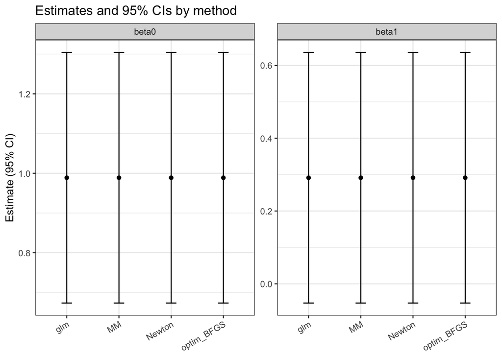

```r
res_long <- res %>%
  tidyr::pivot_longer(
    cols = c(beta0_hat, beta1_hat),
    names_to = "param",
    values_to = "estimate"
  ) %>%
  mutate(
    lwr = ifelse(param == "beta0_hat", beta0_lwr, beta1_lwr),
    upr = ifelse(param == "beta0_hat", beta0_upr, beta1_upr),
    param = ifelse(param == "beta0_hat", "beta0", "beta1")
  )

p1 <- ggplot(res_long, aes(x = method, y = estimate)) +
  geom_point() +
  geom_errorbar(aes(ymin = lwr, ymax = upr), width = 0.2) +
  facet_wrap(~ param, scales = "free_y") +
  labs(x = NULL, y = "Estimate (95% CI)", title = "Estimates and 95% CIs by method") +
  theme_bw() +
  theme(axis.text.x = element_text(angle = 30, hjust = 1))

p1
```

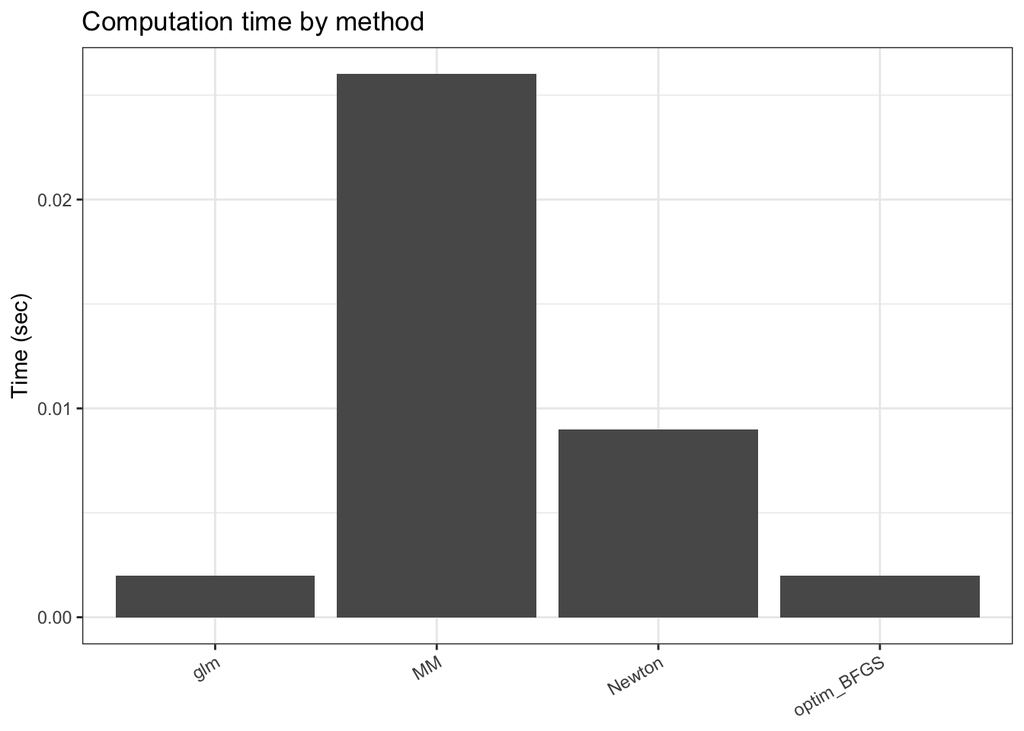

```r
ggsave(here("results", "est_ci_table.png"), plot = p1, width = 8, height = 3, dpi = 300)

p2 <- ggplot(res, aes(x = method, y = time_sec)) +
  geom_col() +
  labs(x = NULL, y = "Time (sec)", title = "Computation time by method") +
  theme_bw() +
  theme(axis.text.x = element_text(angle = 30, hjust = 1))

p2
```

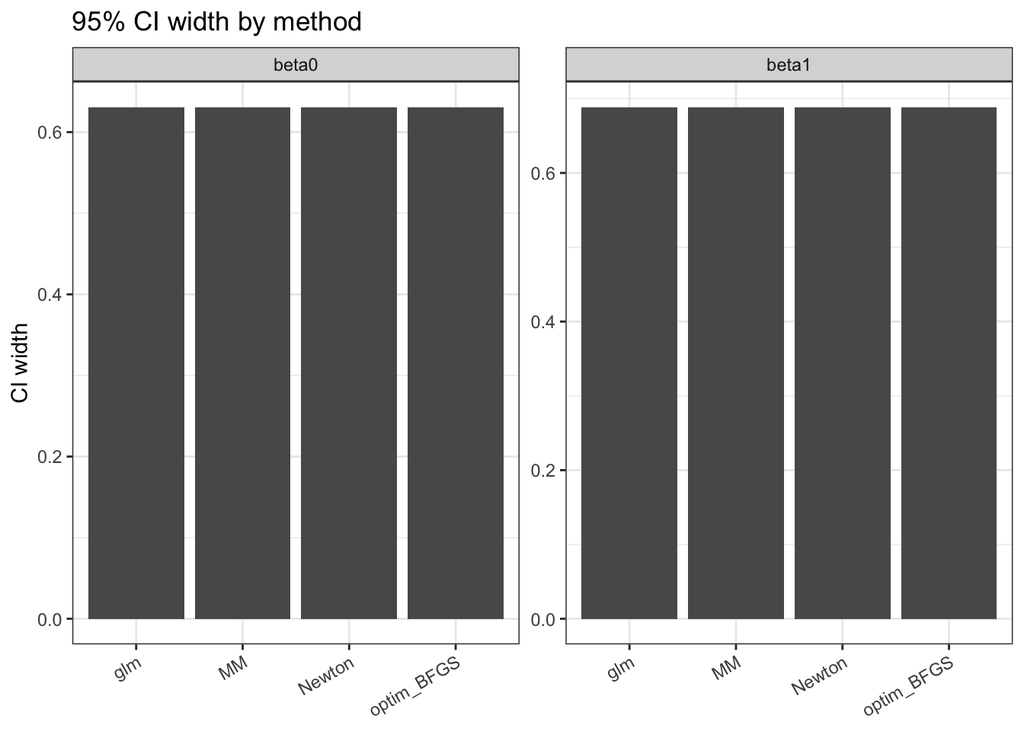

```r
ggsave(here("results", "runtime_iter.png"), plot = p2, width = 8, height = 3, dpi = 300)

res_ciwidth <- res %>%
  mutate(
    ciw_beta0 = beta0_upr - beta0_lwr,
    ciw_beta1 = beta1_upr - beta1_lwr
  ) %>%
  select(method, ciw_beta0, ciw_beta1) %>%
  tidyr::pivot_longer(cols = starts_with("ciw_"),
                      names_to = "param", values_to = "ci_width") %>%
  mutate(param = ifelse(param == "ciw_beta0", "beta0", "beta1"))

p3 <- ggplot(res_ciwidth, aes(x = method, y = ci_width)) +
  geom_col() +
  facet_wrap(~ param, scales = "free_y") +
  labs(x = NULL, y = "CI width", title = "95% CI width by method") +
  theme_bw() +
  theme(axis.text.x = element_text(angle = 30, hjust = 1))

p3
```

```r
ggsave(here("results", "ci_compare.png"), plot = p3, width = 8, height = 3, dpi = 300)
```